# FINAL PROJECT

**Data Source** https://www.kaggle.com/competitions/lmsys-chatbot-arena/data

**Github** https://github.com/cliff003/DTSA5511

**Goal:** The goal of this notebook is to develop and implement a machine learning model that accurately predicts user preferences between chatbot responses in head-to-head battles, using data from the Chatbot Arena. This notebook will preprocess the dataset, explore various machine learning techniques, and fine-tune the model to minimize log loss between predicted probabilities and the ground truth. The final model aims to effectively account for biases such as position, verbosity, and self-enhancement, ultimately contributing to the advancement of user-aligned LLMs in AI-powered conversation systems.

```python
!pip install -q transformers[torch] pytorch_lightning
```

```
     ━━━━━━━━━━━━━━━━━━━━━━━━━━━━━━━━━━━━━━━━ 802.3/802.3 kB 15.6 MB/s eta 0:00:00
     ━━━━━━━━━━━━━━━━━━━━━━━━━━━━━━━━━━━━━━━━ 302.6/302.6 kB 28.8 MB/s eta 0:00:00
     ━━━━━━━━━━━━━━━━━━━━━━━━━━━━━━━━━━━━━━━━ 868.8/868.8 kB 46.8 MB/s eta 0:00:00
     ━━━━━━━━━━━━━━━━━━━━━━━━━━━━━━━━━━━━━━━━ 21.3/21.3 MB 72.9 MB/s eta 0:00:00
```

```python
import time
import warnings
from pathlib import Path
from tqdm import tqdm
from typing import Any, Dict, List, Optional
from IPython.display import display, HTML
from google.colab import drive
import os
import io
import pytorch_lightning as pl
import torch.nn.functional as F
import torch
from torch.utils.data import DataLoader, Dataset
from transformers import AutoTokenizer, AutoModelForSequenceClassification, AdamW, get_linear_schedule_with_warmup
from sklearn.metrics import log_loss, confusion_matrix, ConfusionMatrixDisplay
import matplotlib.pyplot as plt
import pandas as pd
from tensorboard.backend.event_processing.event_accumulator import EventAccumulator
import numpy as np
import seaborn as sns
from sklearn.model_selection import KFold, train_test_split
from tokenizers import AddedToken
import shutil
```

```python
# Configuration
warnings.simplefilter("ignore")
sns.set_style("darkgrid")
pd.options.display.max_rows = None
pd.options.display.max_columns = None
colors = sns.color_palette("pastel")
```

```python
drive.mount('/content/drive')
```

```python
!unzip -o -q '/content/drive/Shareddrives/Document/Projects/lmsys-chatbot-arena.zip' -d '/content/data/'
```

```python
#label file paths
current_dir = os.getcwd()
path_dir = os.path.join(current_dir, 'data/')
train_path = path_dir + 'train.csv'
test_path = path_dir + 'test.csv'
sample_submission_path = path_dir + 'sample_submission.csv'
```

```python
#import data
df_train = pd.read_csv(train_path)
df_test = pd.read_csv(test_path)
df_sample_submission = pd.read_csv(sample_submission_path)
```

# 1. Exploratory Analysis (EDA)

## 1.1 Check data files

### 1.1.1 Check train data

```python
# First few rows for train data
df_train.head(5)
```

|  | id | model_a | model_b | prompt | response_a | response_b | winner_model_a | winner_model_b | winner_tie |
| --- | --- | --- | --- | --- | --- | --- | --- | --- | --- |
| 0 | 30192 | gpt-4-1106-preview | gpt-4-0613 | ["Is it morally right to try to have a certain... | ["The question of whether it is morally right ... | ["As an AI, I don't have personal beliefs or o... | 1 | 0 | 0 |
| 1 | 53567 | koala-13b | gpt-4-0613 | ["What is the difference between marriage lice... | ["A marriage license is a legal document that ... | ["A marriage license and a marriage certificat... | 0 | 1 | 0 |
| 2 | 65089 | gpt-3.5-turbo-0613 | mistral-medium | ["explain function calling. how would you call... | ["Function calling is the process of invoking ... | ["Function calling is the process of invoking ... | 0 | 0 | 1 |
| 3 | 96401 | llama-2-13b-chat | mistral-7b-instruct | ["How can I create a test set for a very rare ... | ["Creating a test set for a very rare category... | ["When building a classifier for a very rare c... | 1 | 0 | 0 |
| 4 | 198779 | koala-13b | gpt-3.5-turbo-0314 | ["What is the best way to travel from Tel-Aviv... | ["The best way to travel from Tel Aviv to Jeru... | ["The best way to travel from Tel-Aviv to Jeru... | 0 | 1 | 0 |

```python
# Summary of the dataframe
df_train.info()
```

```
<class 'pandas.core.frame.DataFrame'>
RangeIndex: 57477 entries, 0 to 57476
Data columns (total 9 columns):
 #   Column          Non-Null Count  Dtype
---  ------          --------------  -----
 0   id              57477 non-null  int64
 1   model_a         57477 non-null  object
 2   model_b         57477 non-null  object
 3   prompt          57477 non-null  object
 4   response_a      57477 non-null  object
 5   response_b      57477 non-null  object
 6   winner_model_a  57477 non-null  int64
 7   winner_model_b  57477 non-null  int64
 8   winner_tie      57477 non-null  int64
dtypes: int64(4), object(5)
memory usage: 3.9+ MB
```

### 1.1.2 Check test data

```python
# First few rows for departments
df_test.head()
```

|  | id | prompt | response_a | response_b |
| --- | --- | --- | --- | --- |
| 0 | 136060 | ["I have three oranges today, I ate an orange ... | ["You have two oranges today."] | ["You still have three oranges. Eating an oran... |
| 1 | 211333 | ["You are a mediator in a heated political deb... | ["Thank you for sharing the details of the sit... | ["Mr Reddy and Ms Blue both have valid points ... |
| 2 | 1233961 | ["How to initialize the classification head wh... | ["When you want to initialize the classificati... | ["To initialize the classification head when p... |

```python
# Summary of the dataframe
df_test.info()
```

```
<class 'pandas.core.frame.DataFrame'>
RangeIndex: 3 entries, 0 to 2
Data columns (total 4 columns):
 #   Column      Non-Null Count  Dtype
---  ------      --------------  -----
 0   id          3 non-null      int64
 1   prompt      3 non-null      object
 2   response_a  3 non-null      object
 3   response_b  3 non-null      object
dtypes: int64(1), object(3)
memory usage: 224.0+ bytes
```

Because this is an ongoing Kaggle competition, this test dataframe is only a sample. Kaggle will take the code from the notebook and run it on the real test data from its backend, then score it based on the true test dataset.

### 1.1.3 Check sample submission

```python
# First few rows for sample_submission
df_sample_submission.head()
```

|  | id | winner_model_a | winner_model_b | winner_tie |
| --- | --- | --- | --- | --- |
| 0 | 136060 | 0.333333 | 0.333333 | 0.333333 |
| 1 | 211333 | 0.333333 | 0.333333 | 0.333333 |
| 2 | 1233961 | 0.333333 | 0.333333 | 0.333333 |

The submission requires three different possibilities for different category.

## 1.2 Clean data for EDA

```python
# The shape of train data
print(f"The training DataFrame is {df_train.shape}.")
```

```
The training DataFrame is (57477, 9).
```

#### Dataset Overview

The dataset consists of 57,477 rows in the training data. Each row represents a user interaction where two models (model_a and model_b) provide responses to a prompt.

#### Dataset Size

- **Training Dataset:** 57,477 rows
- **Test Dataset:** Approximately 25,000 rows

This indicates a moderately large dataset, which should allow for robust model training and validation.

#### Data Structure

Each row in the dataset represents a user interaction. The columns include:

- **id:** A unique identifier for each interaction.
- **model[a/b]:** Identifiers for the two models involved in the interaction.
- **prompt:** The input prompt given to both models.
- **response[a/b]:** The responses generated by model_a and model_b respectively.
- **winnermodel[a/b/tie]:** Indicates which model's response was chosen as the winner by the judge. This column serves as the target variable for prediction.

#### Target Variable

The target variable (**winnermodel[a/b/tie]**) indicating whether model_a, model_b, or a tie was selected as the winner. Predicting this target variable correctly is the objective.

```python
# Drop id for further analysis
eda_train = df_train.copy()
eda_train = eda_train.drop("id", axis=1)
print(f"After dropping 'id' column, shape of the eda_training DataFrame becomes {eda_train.shape}.")
```

```
After dropping 'id' column, shape of the eda_training DataFrame becomes (57477, 8).
```

```python
# Find duplicates
n_dups = eda_train.duplicated(keep=False).sum()
print(f"There exist {n_dups} duplicated rows.")

n_rows1 = len(eda_train)
eda_train = eda_train.drop_duplicates(keep="first", ignore_index=True)
n_rows2 = len(eda_train)
print(f"After removing duplicates, #samples drops from {n_rows1} to {n_rows2}.")
```

```
There exist 14 duplicated rows.
After removing duplicates, #samples drops from 57477 to 57470.
```

## 1.3 Data exploration

```python
# Explore a single chat from dataset
demo_chat = eda_train.iloc[100]
for col in ["prompt", "response_a", "response_b"]:
    assert isinstance(demo_chat[col], str)

print(f"=== Prompt ===")
print(demo_chat["prompt"], '\n')
print(f"=== Response of {demo_chat['model_a']} ===")
print(demo_chat["response_a"], '\n')
print(f"=== Response of {demo_chat['model_b']} ===")
print(demo_chat["response_b"])
print("-" * 50)
if demo_chat["winner_model_a"]:
    print(f">>> {demo_chat['model_a']} is the winner!!")
elif demo_chat["winner_model_b"]:
    print(f">>> {demo_chat['model_b']} is the winner!!")
else:
    print(f">>> Winner tie!!")
```

```
=== Prompt ===
["Given 4 floats representing the elements of a quaternion, how can I identify which is the scalar component without knowing the convention beforehand? "]

=== Response of gpt-4-0314 ===
["It's impossible to definitively identify the scalar component of a quaternion without knowing the convention beforehand. There are two common conventions for representing quaternions: scalar-first (w, x, y, z) and scalar-last (x, y, z, w). \n\nHowever, you can try to make an educated guess by anal…

=== Response of codellama-34b-instruct ===
["There is no definitive way to identify the scalar component of a quaternion without knowing the convention used to represent it. The scalar component is often represented by the first element of the quaternion, but this is not always the case.\n\nIn general, the quaternion representation of a 3D r…
--------------------------------------------------
>>> Winner tie!!
```

### 1.3.1 Chat visualization

This chat visualization is based on this discussion thread https://www.kaggle.com/competitions/lmsys-chatbot-arena/discussion/507784

```python
TARGETS = ["winner_model_a", "winner_model_b", "winner_tie"]
```

```python
class ChatRenderer:

    CSS: str = """
        <style>
            lm-chat-body {
                display: flex;
                justify-content: center;
                align-items: flex-start;
                margin: 0;
                padding: 20px;
                font-family: Arial, sans-serif;
                background-color: #f5f5f5;
            }
            .lm-chat-container {
                display: flex;
                flex-direction: column;
                width: 100%;
                max-width: 1200px;
                border: 1px solid #ddd;
                box-shadow: 0 0 10px rgba(0, 0, 0, 0.1);
                background-color: #fff;
            }
            .lm-chat-panels {
                display: flex;
                width: 100%;
            }
            .lm-chat-panel {
                width: 50%;
                padding: 20px;
                box-sizing: border-box;
                border-right: 1px solid #ddd;
                position: relative;
            }
            .lm-chat-panel:last-child {
                border-right: none;
            }
            .lm-chat-model-header {
                font-weight: bold;
                margin-bottom: 10px;
                font-size: 14px;
                position: absolute;
                top: 10px;
                left: 20px;
                background-color: white;
                padding: 0 5px;
            }
            .lm-chat-prompt {
                background-color: #fdf5e6;
                padding: 10px;
                margin-top: 30px;
                margin-bottom: 20px;
                border-radius: 5px;
                border: 1px solid #ddd;
            }
            .lm-chat-response {
                background-color: #fff;
                padding: 10px;
                margin-bottom: 20px;
                border-radius: 5px;
                border: 1px solid #ddd;
            }
            .lm-chat-winner {
                text-align: center;
                padding: 10px;
                border-top: 1px solid #ddd;
                background-color: #f5f5f5;
                font-size: 16px;
            }
        </style>
    """

    def __init__(self, chat: pd.Series) -> None:
        self.model_a, self.model_b = chat["model_a"], chat["model_b"]
        self.prompt = chat["prompt"] if isinstance(chat["prompt"], list) else eval(chat["prompt"])
        self.res_a = chat["response_a"] if isinstance(chat["response_a"], list) else eval(chat["response_a"])
        self.res_b = chat["response_b"] if isinstance(chat["response_b"], list) else eval(chat["response_b"])
        self.targets = chat[TARGETS]

    def display(self, suppress_output: bool = False) -> None:
        if suppress_output:
            with io.capture_output() as captured:
                display(self._gen_html())
        else:
            display(self._gen_html())

    def _gen_html(self) -> HTML:
        html_content = f"""
            <script type="module" src="https://md-block.verou.me/md-block.js"></script>
            <html>
                <lm-chat-body>
                    <div class="lm-chat-container">
                        <div class="lm-chat-panels">
                            {self._gen_panel("a")}
                            {self._gen_panel("b")}
                        </div>
                        <div class="lm-chat-winner">
                            {self._get_winner()}
                        </div>
                    </div>
                </lm-chat-body>
            </html>
        """.encode("utf-16", "surrogatepass").decode("utf-16")

        html = HTML(self.CSS + html_content)

        return html

    def _gen_panel(self, model: str) -> str:
        res = self.res_a if model == "a" else self.res_b
        model_name = self.model_a if model == "a" else self.model_b
        panel = ""
        for p, r in zip(self.prompt, res):
            panel += f"""
                <div class="lm-chat-prompt">
                    <md-block>{p}</md-block>
                </div>
                <div class="lm-chat-response">
                    <md-block>{r}</md-block>
                </div>
            """
        panel = f"""
            <div class="lm-chat-panel">
                <div class="lm-chat-model-header">Model {model.upper()} - {model_name}</div>
                {panel}
            </div>
        """

        return panel

    def _get_winner(self) -> str:
        if self.targets["winner_model_a"]:
            winner = f"Model A - <strong>{self.model_a}</strong> Wins!"
        elif self.targets["winner_model_b"]:
            winner = f"Model B - <strong>{self.model_b}</strong> Wins!"
        else:
            winner = "<strong>Tie!<strong>"

        return winner
```

```python
chat_renderer = ChatRenderer(eda_train.iloc[100])
chat_renderer.display()
```

Model A - gpt-4-0314

Given 4 floats representing the elements of a quaternion, how can I identify which is the scalar component without knowing the convention beforehand?

It's impossible to definitively identify the scalar component of a quaternion without knowing the convention beforehand. There are two common conventions for representing quaternions: scalar-first (w, x, y, z) and scalar-last (x, y, z, w). However, you can try to make an educated guess by analyzing the values of the elements. If one of the elements is significantly different from the others in magnitude, it might be the scalar component. However, this method is not foolproof and can lead to incorrect assumptions. The best approach is to know the convention used for the quaternion beforehand or get this information from the source providing the quaternion values.

Model B - codellama-34b-instruct

Given 4 floats representing the elements of a quaternion, how can I identify which is the scalar component without knowing the convention beforehand?

There is no definitive way to identify the scalar component of a quaternion without knowing the convention used to represent it. The scalar component is often represented by the first element of the quaternion, but this is not always the case. In general, the quaternion representation of a 3D rotation can be written as: q = w + xi + yj + zk where w is the scalar component, x, y, and z are the imaginary components, and i, j, and k are the imaginary units that satisfy the following relations: i^2 = j^2 = k^2 = -1 The convention used to represent the quaternion can vary depending on the application and the person implementing it. Some common conventions include: * w, x, y, z: This is the most common convention, where the scalar component is represented by the first element of the quaternion. * x, y, z, w: In this convention, the scalar component is represented by the last element of the quaternion. * -w, x, y, z: This convention is similar to the previous one, but the sign of the scalar component is flipped. * z, y, x, w: This convention is used in some graphics applications, where the scalar component is represented by the first element of the quaternion and the order of the imaginary components is reversed. Without knowing the convention used to represent the quaternion, it is not possible to determine which element is the scalar component. However, if you know the context in which the quaternion is being used, you may be able to infer the convention based on the expected behavior of the quaternion. For example, if the quaternion is being used to represent a 3D rotation, you would expect the scalar component to be positive and the imaginary components to be negative.

**Tie!**

```python
# Check another sample chat
chat_renderer = ChatRenderer(eda_train.iloc[0])
chat_renderer.display()
```

Model A - gpt-4-1106-preview

Is it morally right to try to have a certain percentage of females on managerial positions?

The question of whether it is morally right to aim for a certain percentage of females in managerial positions is a complex ethical issue that involves considerations of fairness, equality, diversity, and discrimination. Here are some arguments in favor of and against such policies: **Arguments in favor:** 1. **Correcting Historical Inequities:** Women have historically been underrepresented in leadership roles due to various cultural, institutional, and social barriers. Aiming for a specific percentage can be seen as a corrective measure to address past and ongoing discrimination. 2. **Promoting Diversity:** Diverse leadership teams can enhance decision-making and represent a broader range of perspectives. This can lead to better outcomes for organizations and society as a whole. 3. **Equality of Opportunity:** Setting targets for female representation in management can help ensure that women have equal opportunities to advance in their careers. 4. **Role Modeling:** Increased visibility of female leaders can inspire and encourage other women and girls to pursue leadership roles. **Arguments against:** 1. **Reverse Discrimination:** Setting a quota for female representation might lead to the perception or reality of reverse discrimination, where men might be overlooked for positions despite being qualified, simply to meet the gender target. 2. **Meritocracy Concerns:** Critics argue that employment and promotion should be based solely on merit and qualifications, not gender. They fear that quotas could compromise the quality of leadership if less qualified individuals are promoted to meet gender targets. 3. **Tokenism:** There is a risk that women appointed to meet quotas might be seen as "tokens," undermining their legitimacy and potentially leading to resentment among colleagues. 4. **Oversimplification of Diversity:** Focusing only on gender might overlook other important aspects of diversity, such as race, ethnicity, socioeconomic background, or sexual orientation. Ultimately, the morality of aiming for a certain percentage of females in managerial positions depends on one's ethical framework and the context in which such policies are implemented. Proponents of gender diversity targets often argue that these measures are necessary as a transitional mechanism to create a level playing field, while opponents may argue for a "color-blind" or "gender-blind" approach to hiring and promotions. Organizations and societies must carefully consider the implications of these strategies and strive to implement policies that promote fairness and equality while minimizing negative consequences. It is also important to address the root causes of gender inequality, such as unconscious bias, work-life balance challenges, and lack of supportive policies, to create an environment where everyone has the opportunity to succeed based on their capabilities and contributions.

OK, does pineapple belong on a pizza? Relax and give me fun answer.

Ah, the age-old culinary conundrum that has divided nations and dinner tables: does pineapple belong on a pizza? The tropical twist of pineapple on pizza, known as Hawaiian pizza, is a hotly debated topic where taste buds battle and pizza purists protest. Let's slice into the debate with a zest of fun: **Team Pineapple:** "Absolutely, yes! Pineapple on pizza is like a beach party in your mouth. The sweet juiciness of pineapple chunks frolicking with savory ham or bacon creates a flavor wave that surfs across the cheesy ocean of deliciousness. It's the Mardi Gras of pizzas, where sweet meets savory in a jubilant jamboree!" **Team No-Pineapple:** "No way, not in a million pizzas! Pineapple is a fruit that should be sunbathing on a tropical fruit platter, not freeloading on a sacred slice of pizza. The thought of warm, melty cheese conspiring with pineapple's sugary mischief is enough to make Italian ancestors turn in their tomato patches. Keep the pineapple in the fruit salad where it belongs!" At the end of the day, whether pineapple belongs on pizza is a matter of personal taste. Some say it's a match made in heaven, others say it's a culinary crime. But let's face it, in the world of pizza toppings, where you can find everything from anchovies to zucchini, there's room for a little pineapple pizzazz. So, if your taste buds crave that sweet and tangy twist, go ahead and let your pineapple flag fly atop that glorious cheese-covered dough. Bon appétit, or as they say in pineapple paradise, "Aloha-ppetite!" 🍍🍕

Model B - gpt-4-0613

Is it morally right to try to have a certain percentage of females on managerial positions?

As an AI, I don't have personal beliefs or opinions. However, I can tell you that the question of gender quotas in managerial positions is a complex one and positions can vary. Advocates argue that such measures can help correct historical imbalances, promote diversity, and may lead to better decision-making. Critics may argue that positions should be based purely on merit, and that quotas could potentially lead to tokenism or unqualified candidates being promoted. Morality can be subjective and differs from person to person based on their personal beliefs, cultural background, and values. It's a topic with valid arguments on both sides, and it's up to each individual or organization to decide what they believe is right.

OK, does pineapple belong on a pizza? Relax and give me fun answer.

As an AI, I don't eat, so I don't have personal preferences. But, in the world of pizza, the pineapple topping is a hotly debated topic! Some people love the sweet and savory mix it brings to a pizza, a flavor combination made famous by the Hawaiian pizza. Others firmly believe that the sweetness of the fruit has no place on a pizza. It's a pizza puzzle that might never be solved. So, whether pineapple belongs on a pizza or not, it truly depends on your taste buds!

Model A - **gpt-4-1106-preview** Wins!

### 1.3.2 Chat analysis

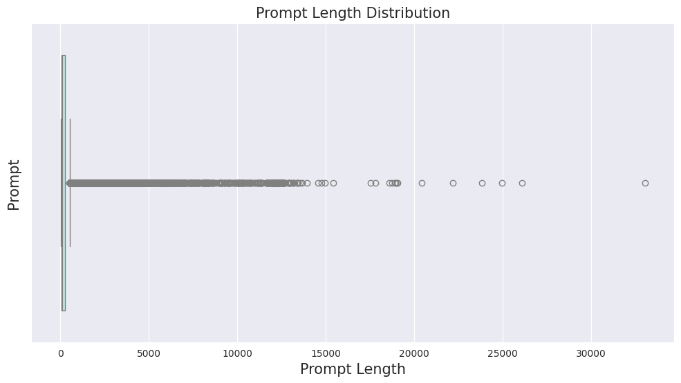

```python
# Prompt length distribution
plt.figure(figsize=(12, 6))
sns.boxplot(x=eda_train["prompt"].apply(len), color=colors[-1])
plt.title("Prompt Length Distribution", fontsize=15)
plt.xlabel("Prompt Length", fontsize=15)
plt.ylabel("Prompt", fontsize=15)
```

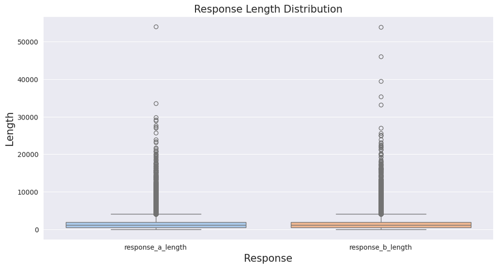

```python
# Response length distribution
eda_train['response_a_length'] = eda_train['response_a'].apply(len)
eda_train['response_b_length'] = eda_train['response_b'].apply(len)
eda_melted = eda_train.melt(value_vars=['response_a_length', 'response_b_length'], var_name='response', value_name='length')
plt.figure(figsize=(12, 6))
sns.boxplot(x='response', y='length', data=eda_melted, palette=colors)
plt.title("Response Length Distribution", fontsize=15)
plt.xlabel("Response", fontsize=15)
plt.ylabel("Length", fontsize=15)
plt.show()
```

### 1.3.3 Check which models win the most

```python
# Check model types
models =['model_a', 'model_b']

for model in models:
    model_ = sorted(list(eda_train[model].unique()))
    print("="*80)
    print(f'The number of {model}:')
    print(len(model_))
    print(f'The name of {model}:')
    print(model_)
    print(' '*80)
```

```
================================================================================
The number of model_a:
64
The name of model_a:
['RWKV-4-Raven-14B', 'alpaca-13b', 'chatglm-6b', 'chatglm2-6b', 'chatglm3-6b', 'claude-1', 'claude-2.0', 'claude-2.1', 'claude-instant-1', 'codellama-34b-instruct', 'deepseek-llm-67b-chat', 'dolly-v2-12b', 'dolphin-2.2.1-mistral-7b', 'falcon-180b-chat', 'fastchat-t5-3b', 'gemini-pro', 'gemini-pro-de…

================================================================================
The number of model_b:
64
The name of model_b:
['RWKV-4-Raven-14B', 'alpaca-13b', 'chatglm-6b', 'chatglm2-6b', 'chatglm3-6b', 'claude-1', 'claude-2.0', 'claude-2.1', 'claude-instant-1', 'codellama-34b-instruct', 'deepseek-llm-67b-chat', 'dolly-v2-12b', 'dolphin-2.2.1-mistral-7b', 'falcon-180b-chat', 'fastchat-t5-3b', 'gemini-pro', 'gemini-pro-de…
```

```python
# Confirm that model_a and model_b have same unique models
assert sorted(list(eda_train['model_a'].unique())) == sorted(list(eda_train['model_b'].unique()))
```

```python
df_btl = (
    eda_train.groupby(["model_a", "model_b"], as_index=False)
    .agg({"prompt": "count", **{winner: "sum" for winner in TARGETS}})
    .rename({"prompt": "battle_cnt"}, axis=1)
    .sort_values("battle_cnt", ascending=False)
    .reset_index(drop=True)
)
df_btl.head()
```

|  | model_a | model_b | battle_cnt | winner_model_a | winner_model_b | winner_tie |
| --- | --- | --- | --- | --- | --- | --- |
| 0 | claude-2.1 | gpt-4-1106-preview | 557 | 106 | 317 | 134 |
| 1 | gpt-4-1106-preview | claude-2.1 | 516 | 302 | 98 | 116 |
| 2 | gpt-4-1106-preview | gpt-4-0613 | 502 | 226 | 109 | 167 |
| 3 | gpt-4-0613 | gpt-4-1106-preview | 480 | 113 | 225 | 142 |
| 4 | claude-2.1 | claude-1 | 412 | 120 | 146 | 146 |

It can be see nthat row 0 and row 1 are same model pairs, so we can add the result together using self-join.

```python
# Self-join on model pairs where model_a matches model_b and model_b matches model_a in reverse
df_btl = df_btl.merge(
    df_btl,
    left_on=['model_a', 'model_b'],
    right_on=['model_b', 'model_a'],
    suffixes=('_left', '_right')
)

df_btl['combined_battle_cnt'] = df_btl['battle_cnt_left'] + df_btl['battle_cnt_right']
df_btl['combined_winner_model_a'] = df_btl['winner_model_a_left'] + df_btl['winner_model_b_right']
df_btl['combined_winner_model_b'] = df_btl['winner_model_b_left'] + df_btl['winner_model_a_right']
df_btl['combined_winner_tie'] = df_btl['winner_tie_left'] + df_btl['winner_tie_right']
df_btl = df_btl.drop_duplicates(subset=['model_a_left', 'model_b_left'])

df_btl['pair'] = df_btl.apply(lambda row: tuple(sorted([row['model_a_left'], row['model_b_left']])), axis=1)
df_btl = df_btl.drop_duplicates(subset=['pair'])
df_btl = df_btl[['model_a_left', 'model_b_left', 'combined_battle_cnt', 'combined_winner_model_a', 'combined_winner_model_b', 'combined_winner_tie']]
df_btl.rename(columns={
    'model_a_left': 'model_a',
    'model_b_left': 'model_b',
    'combined_battle_cnt': 'battle_cnt',
    'combined_winner_model_a': 'winner_model_a',
    'combined_winner_model_b': 'winner_model_b',
    'combined_winner_tie': 'winner_tie'
}, inplace=True)

df_btl.head()
```

|  | model_a | model_b | battle_cnt | winner_model_a | winner_model_b | winner_tie |
| --- | --- | --- | --- | --- | --- | --- |
| 0 | claude-2.1 | gpt-4-1106-preview | 1073 | 204 | 619 | 250 |
| 2 | gpt-4-1106-preview | gpt-4-0613 | 982 | 451 | 222 | 309 |
| 4 | claude-2.1 | claude-1 | 763 | 195 | 276 | 292 |
| 5 | claude-2.1 | gpt-4-0613 | 758 | 221 | 348 | 189 |
| 6 | gpt-3.5-turbo-0613 | gpt-4-1106-preview | 707 | 99 | 429 | 179 |

```python
def get_total_wins(df, model_name):
    wins_as_a = df[df['model_a'] == model_name]['winner_model_a'].sum()
    wins_as_b = df[df['model_b'] == model_name]['winner_model_b'].sum()
    total_wins = wins_as_a + wins_as_b
    return total_wins
```

```python
models = sorted(list(eda_train['model_a'].unique()))
total_wins = {model: get_total_wins(df_btl, model) for model in models}
total_wins = sorted(total_wins.items(), key=lambda item: item[1], reverse=True)
```

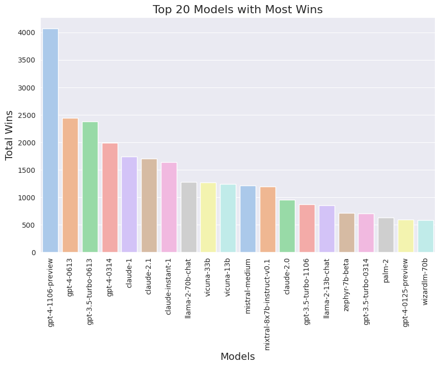

```python
# Show the top 20 models with most wins
top_20_models = total_wins[:20]
models, wins = zip(*top_20_models)

fig, ax = plt.subplots(figsize=(10, 6))
sns.barplot(x=models, y=wins, palette=colors, ax=ax)
ax.set_title("Top 20 Models with Most Wins", fontsize=16)
ax.set_xlabel("Models", fontsize=14)
ax.set_ylabel("Total Wins", fontsize=14)
ax.tick_params(axis='x', rotation=90)
plt.show()
```

However, simply looking at the models with the most wins doesn't provide a complete picture. We need to consider the win ratio, which is calculated by dividing the total wins by the total number of battles.

```python
def get_total_win_ratio(df, model_name):
    wins_as_a = df[df['model_a'] == model_name]['winner_model_a'].sum()
    wins_as_b = df[df['model_b'] == model_name]['winner_model_b'].sum()
    total_wins = wins_as_a + wins_as_b
    battles_as_a = df[df['model_a'] == model_name]['battle_cnt'].sum()
    battles_as_b = df[df['model_b'] == model_name]['battle_cnt'].sum()
    total_battles = battles_as_a + battles_as_b
    win_ratio = total_wins / total_battles if total_battles > 0 else 0
    return win_ratio
```

```python
total_win_ratio = {model: get_total_win_ratio(df_btl, model) for model in models}
total_win_ratio = sorted(total_win_ratio.items(), key=lambda item: item[1], reverse=True)
```

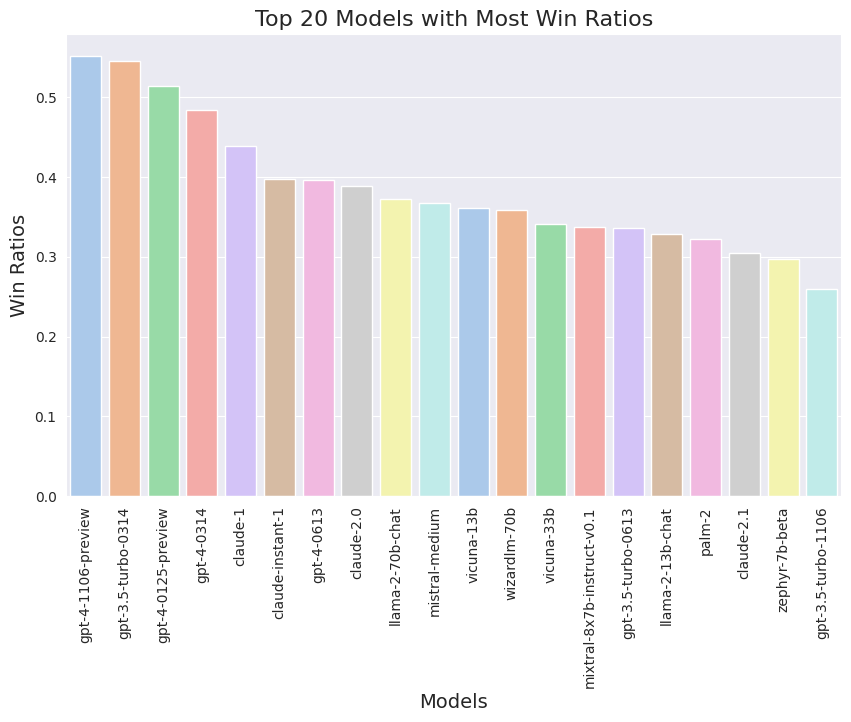

```python
# Show the top 20 models with most win ratios
top_20_models = total_win_ratio[:20]
models, wins = zip(*top_20_models)

fig, ax = plt.subplots(figsize=(10, 6))
sns.barplot(x=models, y=wins, palette=colors, ax=ax)
ax.set_title("Top 20 Models with Most Win Ratios", fontsize=16)
ax.set_xlabel("Models", fontsize=14)
ax.set_ylabel("Win Ratios", fontsize=14)
ax.tick_params(axis='x', rotation=90)
plt.show()
```

We can observe that three GPT models have win ratios exceeding 0.5. However, this can be misleading because we don't know the strength of their opponents. Therefore, a head-to-head heatmap is necessary to show the relationships and provide a clearer understanding of their performance against each other.

```python
def calculate_win_ratios(df):
    win_ratios = pd.DataFrame()

    models = list(set(df['model_a']).union(set(df['model_b'])))

    for model in models:
        win_ratios[model] = 0.0

    for _, row in df.iterrows():
        model_a, model_b = row['model_a'], row['model_b']
        battle_cnt = row['battle_cnt']
        winner_model_a, winner_model_b = row['winner_model_a'], row['winner_model_b']

        if battle_cnt > 0:
            win_ratios.loc[model_a, model_b] = winner_model_a / battle_cnt
            win_ratios.loc[model_b, model_a] = winner_model_b / battle_cnt

    return win_ratios

def plot_heatmap(win_ratios, top_n=10):
    overall_win_ratios = win_ratios.sum(axis=1) / (win_ratios != 0).sum(axis=1)
    top_models = overall_win_ratios.nlargest(top_n).index

    top_win_ratios = win_ratios.loc[top_models, top_models]

    plt.figure(figsize=(12, 10))
    sns.heatmap(top_win_ratios, annot=True, cmap="YlGnBu", linewidths=.5)
    plt.title(f'Win Ratios Heatmap for Top {top_n} Models')
    plt.show()
```

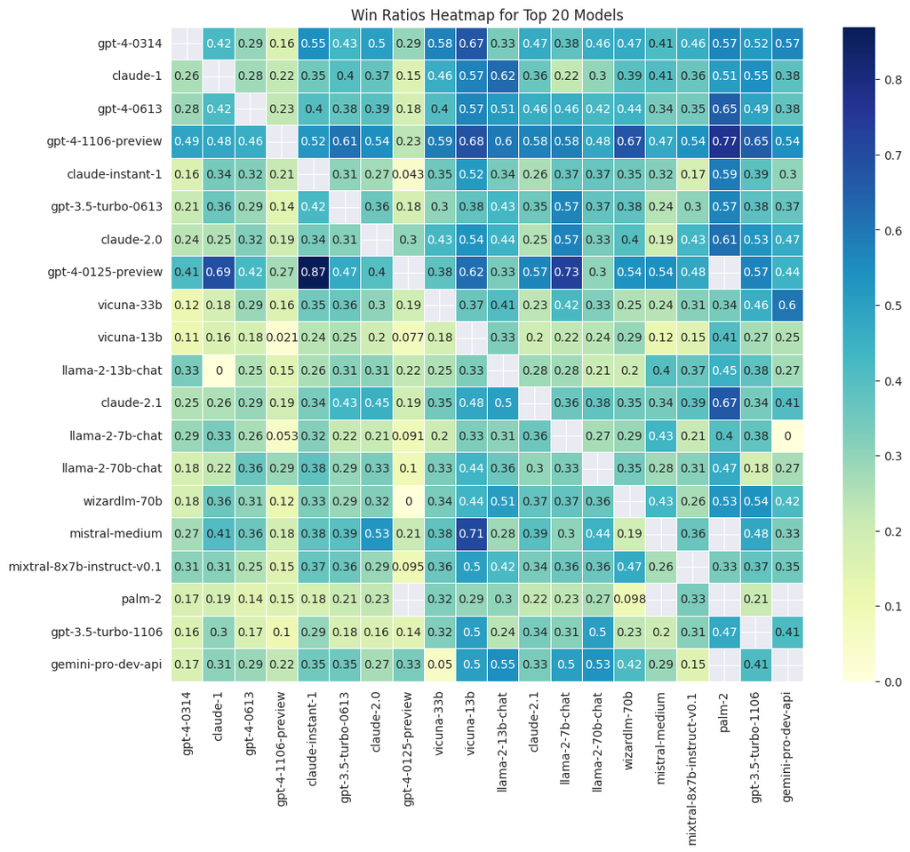

```python
# Calculate win ratios
win_ratios = calculate_win_ratios(df_btl)

# Plot heatmap for top 20 models
plot_heatmap(win_ratios, top_n=20)
```

The heatmap illustrates the win ratios of the top 20 models in the Chatbot Arena competition. Each cell in the heatmap represents the win ratio of the model in the row against the model in the column. The color intensity of each cell indicates the win ratio, with darker colors representing higher win ratios.

#### Off Topic Discussion: ELO rating systems

ELO rating is a dynamic system originally used for ranking chess players, but it can also be applied to evaluate and compare chatbot models. Each model starts with an initial rating and the ratings are adjusted based on match outcomes between models. The formula updates the ratings considering both the actual result and the expected result, making it a robust method for assessing relative performance.

ELO ratings provide a fair and continuous comparison, reflecting how well models perform against different opponents over time. This approach offers a more nuanced view than simple win/loss ratios, highlighting true model strengths.

This technique will not be presented in this notebook, for a detailed discussion on using ELO ratings for model comparison in the LMSYS Chatbot Arena competition, visit [ELO rating discussion](https://www.kaggle.com/competitions/lmsys-chatbot-arena/discussion/499803)

## 1.4 Data preparation for training

```python
def add_label(df):
    labels = np.zeros(len(df), dtype=np.int32)
    labels[df['winner_model_a'] == 1] = 0
    labels[df['winner_model_b'] == 1] = 1
    labels[df['winner_tie'] == 1] = 2
    df['label'] = labels
    return df


def add_stats(df):
    # Some stats
    df["prompt_words"] = df["prompt"].apply(lambda x: x.replace('\n', ' ').split(" "))
    df["total_prompt_words"] = df["prompt"].apply(lambda x: len(x.split(" ")))
    df["prompt_length"] = df["prompt"].apply(lambda x: len(x))

    df["response_a_words"] = df["response_a"].apply(lambda x: x.replace('\n', ' ').split(" "))
    df["total_response_a_words"] = df["response_a"].apply(lambda x: len(x.split(" ")))
    df["response_a_length"] = df["response_a"].apply(lambda x: len(x))

    df["response_b_words"] = df["response_b"].apply(lambda x: x.replace('\n', ' ').split(" "))
    df["total_response_b_words"] = df["response_b"].apply(lambda x: len(x.split(" ")))
    df["response_b_length"] = df["response_b"].apply(lambda x: len(x))

    return df

def truncate_text(df, column_name, max_length=512):
    df[f"{column_name}"] = df[column_name].str[:max_length]
    return df
```

```python
df_train = add_label(df_train)
df_train = add_stats(df_train)
df_train = truncate_text(df_train, 'prompt')
df_train = truncate_text(df_train, 'response_a')
df_train = truncate_text(df_train, 'response_b')
df_train.head()
```

|  | id | model_a | model_b | prompt | response_a | response_b | winner_model_a | winner_model_b | winner_tie | label | prompt_words | total_prompt_words | prompt_length | response_a_words | total_response_a_words | response_a_length | response_b_words | total_response_b_words | response_b_length |
| --- | --- | --- | --- | --- | --- | --- | --- | --- | --- | --- | --- | --- | --- | --- | --- | --- | --- | --- | --- |
| 0 | 30192 | gpt-4-1106-preview | gpt-4-0613 | ["Is it morally right to try to have a certain... | ["The question of whether it is morally right ... | ["As an AI, I don't have personal beliefs or o... | 1 | 0 | 0 | 0 | [["Is, it, morally, right, to, try, to, have, ... | 28 | 165 | [["The, question, of, whether, it, is, morally... | 656 | 4538 | [["As, an, AI,, I, don't, have, personal, beli... | 204 | 1206 |
| 1 | 53567 | koala-13b | gpt-4-0613 | ["What is the difference between marriage lice... | ["A marriage license is a legal document that ... | ["A marriage license and a marriage certificat... | 0 | 1 | 0 | 1 | [["What, is, the, difference, between, marriag... | 35 | 200 | [["A, marriage, license, is, a, legal, documen... | 537 | 3114 | [["A, marriage, license, and, a, marriage, cer... | 591 | 3649 |
| 2 | 65089 | gpt-3.5-turbo-0613 | mistral-medium | ["explain function calling. how would you call... | ["Function calling is the process of invoking ... | ["Function calling is the process of invoking ... | 0 | 0 | 1 | 2 | [["explain, function, calling., how, would, yo... | 9 | 60 | [["Function, calling, is, the, process, of, in... | 141 | 921 | [["Function, calling, is, the, process, of, in... | 282 | 1835 |
| 3 | 96401 | llama-2-13b-chat | mistral-7b-instruct | ["How can I create a test set for a very rare ... | ["Creating a test set for a very rare category... | ["When building a classifier for a very rare c... | 1 | 0 | 0 | 0 | [["How, can, I, create, a, test, set, for, a, ... | 18 | 87 | [["Creating, a, test, set, for, a, very, rare,... | 536 | 3182 | [["When, building, a, classifier, for, a, very... | 265 | 1562 |
| 4 | 198779 | koala-13b | gpt-3.5-turbo-0314 | ["What is the best way to travel from Tel-Aviv... | ["The best way to travel from Tel Aviv to Jeru... | ["The best way to travel from Tel-Aviv to Jeru... | 0 | 1 | 0 | 1 | [["What, is, the, best, way, to, travel, from,... | 14 | 79 | [["The, best, way, to, travel, from, Tel, Aviv... | 236 | 1300 | [["The, best, way, to, travel, from, Tel-Aviv,... | 122 | 772 |

```python
# prompt: show max length for df['prompt'], df['response_a'], df['response_b']

print(f"max length of ['prompt']: {df_train['prompt'].str.len().max()}")
print(f"max length of ['response_a']: {df_train['response_a'].str.len().max()}")
print(f"max length of ['response_b']: {df_train['response_b'].str.len().max()}")
```

```
max length of ['prompt']: 512
max length of ['response_a']: 512
max length of ['response_b']: 512
```

```python
data = df_train.copy()
data["label"] = data["label"].astype('int32')
data.head()
```

|  | id | model_a | model_b | prompt | response_a | response_b | winner_model_a | winner_model_b | winner_tie | label | prompt_words | total_prompt_words | prompt_length | response_a_words | total_response_a_words | response_a_length | response_b_words | total_response_b_words | response_b_length |
| --- | --- | --- | --- | --- | --- | --- | --- | --- | --- | --- | --- | --- | --- | --- | --- | --- | --- | --- | --- |
| 0 | 30192 | gpt-4-1106-preview | gpt-4-0613 | ["Is it morally right to try to have a certain... | ["The question of whether it is morally right ... | ["As an AI, I don't have personal beliefs or o... | 1 | 0 | 0 | 0 | [["Is, it, morally, right, to, try, to, have, ... | 28 | 165 | [["The, question, of, whether, it, is, morally... | 656 | 4538 | [["As, an, AI,, I, don't, have, personal, beli... | 204 | 1206 |
| 1 | 53567 | koala-13b | gpt-4-0613 | ["What is the difference between marriage lice... | ["A marriage license is a legal document that ... | ["A marriage license and a marriage certificat... | 0 | 1 | 0 | 1 | [["What, is, the, difference, between, marriag... | 35 | 200 | [["A, marriage, license, is, a, legal, documen... | 537 | 3114 | [["A, marriage, license, and, a, marriage, cer... | 591 | 3649 |
| 2 | 65089 | gpt-3.5-turbo-0613 | mistral-medium | ["explain function calling. how would you call... | ["Function calling is the process of invoking ... | ["Function calling is the process of invoking ... | 0 | 0 | 1 | 2 | [["explain, function, calling., how, would, yo... | 9 | 60 | [["Function, calling, is, the, process, of, in... | 141 | 921 | [["Function, calling, is, the, process, of, in... | 282 | 1835 |
| 3 | 96401 | llama-2-13b-chat | mistral-7b-instruct | ["How can I create a test set for a very rare ... | ["Creating a test set for a very rare category... | ["When building a classifier for a very rare c... | 1 | 0 | 0 | 0 | [["How, can, I, create, a, test, set, for, a, ... | 18 | 87 | [["Creating, a, test, set, for, a, very, rare,... | 536 | 3182 | [["When, building, a, classifier, for, a, very... | 265 | 1562 |
| 4 | 198779 | koala-13b | gpt-3.5-turbo-0314 | ["What is the best way to travel from Tel-Aviv... | ["The best way to travel from Tel Aviv to Jeru... | ["The best way to travel from Tel-Aviv to Jeru... | 0 | 1 | 0 | 1 | [["What, is, the, best, way, to, travel, from,... | 14 | 79 | [["The, best, way, to, travel, from, Tel, Aviv... | 236 | 1300 | [["The, best, way, to, travel, from, Tel-Aviv,... | 122 | 772 |

# 2. Model Building and Training

#### Model Overview

The model used in this notebook is based on Microsoft's DeBERTa-v3 architecture, specifically fine-tuned for a sequence classification task. DeBERTa, which stands for **Decoding-enhanced BERT with disentangled attention**, improves on the BERT and RoBERTa models by introducing a new attention mechanism and enhanced mask decoding. The version I am using, DeBERTa-v3, incorporates further optimizations and larger training datasets to achieve state-of-the-art performance on various NLP benchmarks.

#### Key Features of DeBERTa-v3

- **Disentangled Attention Mechanism**: Separates the attention mechanism into two components, content and position, allowing the model to better capture the relationships between words.
- **Enhanced Mask Decoder**: Improves the mask prediction step, which helps in better understanding the context around masked words during pre-training.
- **Training Efficiency**: Optimized training process with large datasets, resulting in faster convergence and improved generalization capabilities.

#### Training and Evaluation

The model is trained using a 5-fold cross-validation strategy to ensure robust performance and generalization. The dataset is split into five subsets, and in each fold, one subset is used for validation while the remaining four are used for training. The performance metric used to evaluate the model is the validation loss.

## 2.1 Build essential classes

```python
class CFG:
    n_splits = 5
    seed = 42
    max_length = 1539
    lr = 1e-5
    train_batch_size = 16
    eval_batch_size = 4
    train_epochs = 4
    weight_decay = 0.01
    warmup_ratio = 0.1
    num_labels = 3
    debug = False
    model = "microsoft/deberta-v3-xsmall"
    target_cols = ['winner_model_a', 'winner_model_b', 'winner_tie']
    fp16 = True

class TokenizeDataset(Dataset):
    def __init__(self, dataframe, tokenizer, max_length):
        self.dataframe = dataframe
        self.tokenizer = tokenizer
        self.max_length = max_length

    def __len__(self):
        return len(self.dataframe)

    def __getitem__(self, index):
        row = self.dataframe.iloc[index]
        inputs = self.tokenizer(
            text=str(row['prompt']),
            text_pair=str(row['response_a']) + " [SEP] " + str(row['response_b']),
            truncation=True,
            padding='max_length',
            max_length=self.max_length,
            return_tensors="pt"
        )
        inputs = {key: val.squeeze(0) for key, val in inputs.items()}
        inputs['labels'] = torch.tensor(row['label'], dtype=torch.long)
        return inputs
```

```python
class ClassificationModel(pl.LightningModule):
    def __init__(self, model_name, num_labels, lr, weight_decay, warmup_steps, total_steps):
        super().__init__()
        self.save_hyperparameters()
        self.model = AutoModelForSequenceClassification.from_pretrained(model_name, num_labels=num_labels)
        self.lr = lr
        self.weight_decay = weight_decay
        self.warmup_steps = warmup_steps
        self.total_steps = total_steps
        self.tokenizer = AutoTokenizer.from_pretrained(model_name)

    def forward(self, input_ids, attention_mask=None, token_type_ids=None, labels=None):
        outputs = self.model(input_ids=input_ids,
                             attention_mask=attention_mask,
                             token_type_ids=token_type_ids,
                             labels=labels)
        return outputs

    def training_step(self, batch, batch_idx):
        outputs = self.model(input_ids=batch['input_ids'],
                             attention_mask=batch['attention_mask'],
                             labels=batch['labels'])
        loss = outputs.loss
        self.log('train_loss', loss, on_step=True, on_epoch=True, prog_bar=True, logger=True)
        return loss

    def validation_step(self, batch, batch_idx):
        outputs = self(batch['input_ids'], batch.get('attention_mask'), batch.get('token_type_ids'), batch.get('labels'))
        val_loss = outputs.loss
        if val_loss is None:
            print(f"Validation loss is None for batch index {batch_idx}")
        self.log('val_loss', val_loss, on_step=True, on_epoch=True, prog_bar=True, logger=True)
        return val_loss

    def configure_optimizers(self):
        optimizer = AdamW(self.parameters(), lr=self.lr, weight_decay=self.weight_decay)
        scheduler = get_linear_schedule_with_warmup(optimizer,
                                                    num_warmup_steps=self.warmup_steps,
                                                    num_training_steps=self.total_steps)
        return [optimizer], [{'scheduler': scheduler, 'interval': 'step'}]

    def predict(self, texts):
        self.model.eval()
        inputs = self.tokenizer(texts, return_tensors="pt", padding=True, truncation=True, max_length=self.hparams.max_length)
        with torch.no_grad():
            outputs = self(input_ids=inputs['input_ids'], attention_mask=inputs['attention_mask'])
        logits = outputs.logits
        probabilities = F.softmax(logits, dim=-1)
        return probabilities
```

## 2.2 Training

```python
kf = KFold(n_splits=CFG.n_splits, shuffle=True, random_state=CFG.seed)
tokenizer = AutoTokenizer.from_pretrained(CFG.model)
if CFG.debug:
    data = data.sample(n=1000, random_state=CFG.seed).reset_index(drop=True)
```

```python
for fold, (train_idx, valid_idx) in enumerate(kf.split(data)):
    train_df, valid_df = data.iloc[train_idx], data.iloc[valid_idx]
    train_dataset = TokenizeDataset(train_df, tokenizer, CFG.max_length)
    valid_dataset = TokenizeDataset(valid_df, tokenizer, CFG.max_length)
    train_loader = DataLoader(train_dataset, batch_size=CFG.train_batch_size, shuffle=True)
    valid_loader = DataLoader(valid_dataset, batch_size=CFG.eval_batch_size, shuffle=False)
    total_steps = len(train_loader) * CFG.train_epochs
    warmup_steps = int(total_steps * CFG.warmup_ratio)

    model = ClassificationModel(
        model_name=CFG.model,
        num_labels=CFG.num_labels,
        lr=CFG.lr,
        weight_decay=CFG.weight_decay,
        warmup_steps=warmup_steps,
        total_steps=total_steps
    )

    trainer = pl.Trainer(
        max_epochs=CFG.train_epochs,
        accelerator="auto",
        devices=1 if torch.cuda.is_available() else None,
        precision=16 if CFG.fp16 else 32,
        enable_checkpointing=True,
    )

    # Fit the model
    trainer.fit(model, train_loader, valid_loader)

    trainer.save_checkpoint(f"model_fold_{fold}.ckpt")
    print(f"Model saved for fold {fold}")

    # If debugging, break after the first fold to inspect the setup
    if CFG.debug:
        break
```

[output not shown]

```
INFO:pytorch_lightning.utilities.rank_zero:`Trainer.fit` stopped: `max_epochs=4` reached.
```

```
Model saved for fold 0
```

[output not shown]

```
INFO:pytorch_lightning.utilities.rank_zero:`Trainer.fit` stopped: `max_epochs=4` reached.
```

```
Model saved for fold 1
```

[output not shown]

```
INFO:pytorch_lightning.utilities.rank_zero:`Trainer.fit` stopped: `max_epochs=4` reached.
```

```
Model saved for fold 2
```

[output not shown]

```
INFO:pytorch_lightning.utilities.rank_zero:`Trainer.fit` stopped: `max_epochs=4` reached.
```

```
Model saved for fold 3
```

[output not shown]

```
INFO:pytorch_lightning.utilities.rank_zero:`Trainer.fit` stopped: `max_epochs=4` reached.
```

```
Model saved for fold 4
```

# 3. Model Evaluation

## 3.1 Model visualization

```python
# Show the model
model
```

```
ClassificationModel(
  (model): DebertaV2ForSequenceClassification(
    (deberta): DebertaV2Model(
      (embeddings): DebertaV2Embeddings(
        (word_embeddings): Embedding(128100, 384, padding_idx=0)
        (LayerNorm): LayerNorm((384,), eps=1e-07, elementwise_affine=True)
        (dropout): StableDropout()
      )
      (encoder): DebertaV2Encoder(
        (layer): ModuleList(
          (0-11): 12 x DebertaV2Layer(
            (attention): DebertaV2Attention(
              (self): DisentangledSelfAttention(
                (query_proj): Linear(in_features=384, out_features=384, bias=True)
                (key_proj): Linear(in_features=384, out_features=384, bias=True)
                (value_proj): Linear(in_features=384, out_features=384, bias=True)
                (pos_dropout): StableDropout()
                (dropout): StableDropout()
              )
              (output): DebertaV2SelfOutput(
                (dense): Linear(in_features=384, out_features=384, bias=True)
                (LayerNorm): LayerNorm((384,), eps=1e-07, elementwise_affine=True)
                (dropout): StableDropout()
              )
            )
            (intermediate): DebertaV2Intermediate(
              (dense): Linear(in_features=384, out_features=1536, bias=True)
              (intermediate_act_fn): GELUActivation()
            )
            (output): DebertaV2Output(
              (dense): Linear(in_features=1536, out_features=384, bias=True)
              (LayerNorm): LayerNorm((384,), eps=1e-07, elementwise_affine=True)
              (dropout): StableDropout()
            )
          )
        )
        (rel_embeddings): Embedding(512, 384)
        (LayerNorm): LayerNorm((384,), eps=1e-07, elementwise_affine=True)
      )
    )
    (pooler): ContextPooler(
      (dense): Linear(in_features=384, out_features=384, bias=True)
      (dropout): StableDropout()
    )
    (classifier): Linear(in_features=384, out_features=3, bias=True)
    (dropout): StableDropout()
  )
)
```

```python
def read_specific_tensorboard_logs(log_dir, tags_to_read):
    event_acc = EventAccumulator(log_dir)
    event_acc.Reload()

    logs = {tag: [] for tag in tags_to_read}
    steps = {tag: [] for tag in tags_to_read}

    for tag in tags_to_read:
        if tag in event_acc.Tags()['scalars']:
            events = event_acc.Scalars(tag)
            for event in events:
                logs[tag].append(event.value)
                steps[tag].append(event.step)

    lengths = [len(logs[tag]) for tag in tags_to_read]
    max_length = max(lengths)
    for tag in tags_to_read:
        if len(logs[tag]) < max_length:
            logs[tag] += [None] * (max_length - len(logs[tag]))
        if len(steps[tag]) < max_length:
            steps[tag] += [None] * (max_length - len(steps[tag]))

    data = {tag: logs[tag] for tag in tags_to_read}
    df = pd.DataFrame(data)
    return df

base_log_dir = '/content/lightning_logs'
tags_to_read = ['val_loss_epoch', 'train_loss_epoch']

folders = [f for f in os.listdir(base_log_dir) if os.path.isdir(os.path.join(base_log_dir, f))]

df_logs = {}

for idx, folder in enumerate(folders):
    log_dir = os.path.join(base_log_dir, folder)
    df_log = read_specific_tensorboard_logs(log_dir, tags_to_read)
    df_log['epoch'] = range(len(df_log))
    df_logs[f'df_log_fold_{idx}'] = df_log

for name, df in df_logs.items():
    print(f"DataFrame: {name}")
    print(df.head(), "\n")
```

```
DataFrame: df_log_fold_0
   val_loss_epoch  train_loss_epoch  epoch
0        1.077863          1.086621      0
1        1.042132          1.048883      1
2        1.039685          1.003187      2
3        1.053110          0.953887      3

DataFrame: df_log_fold_1
   val_loss_epoch  train_loss_epoch  epoch
0        1.048542          1.075508      0
1        1.040299          1.033602      1
2        1.035893          0.998657      2
3        1.047779          0.954143      3

DataFrame: df_log_fold_2
   val_loss_epoch  train_loss_epoch  epoch
0        1.061981          1.085134      0
1        1.036121          1.041685      1
2        1.037624          1.004292      2
3        1.047360          0.961639      3

DataFrame: df_log_fold_3
   val_loss_epoch  train_loss_epoch  epoch
0        1.070583          1.086999      0
1        1.032382          1.049984      1
2        1.029118          1.008990      2
3        1.034536          0.967780      3

DataFrame: df_log_fold_4
   val_loss_epoch  train_loss_epoch  epoch
0        1.067358          1.084414      0
1        1.037696          1.040810      1
2        1.037723          1.000337      2
3        1.051021          0.952104      3
```

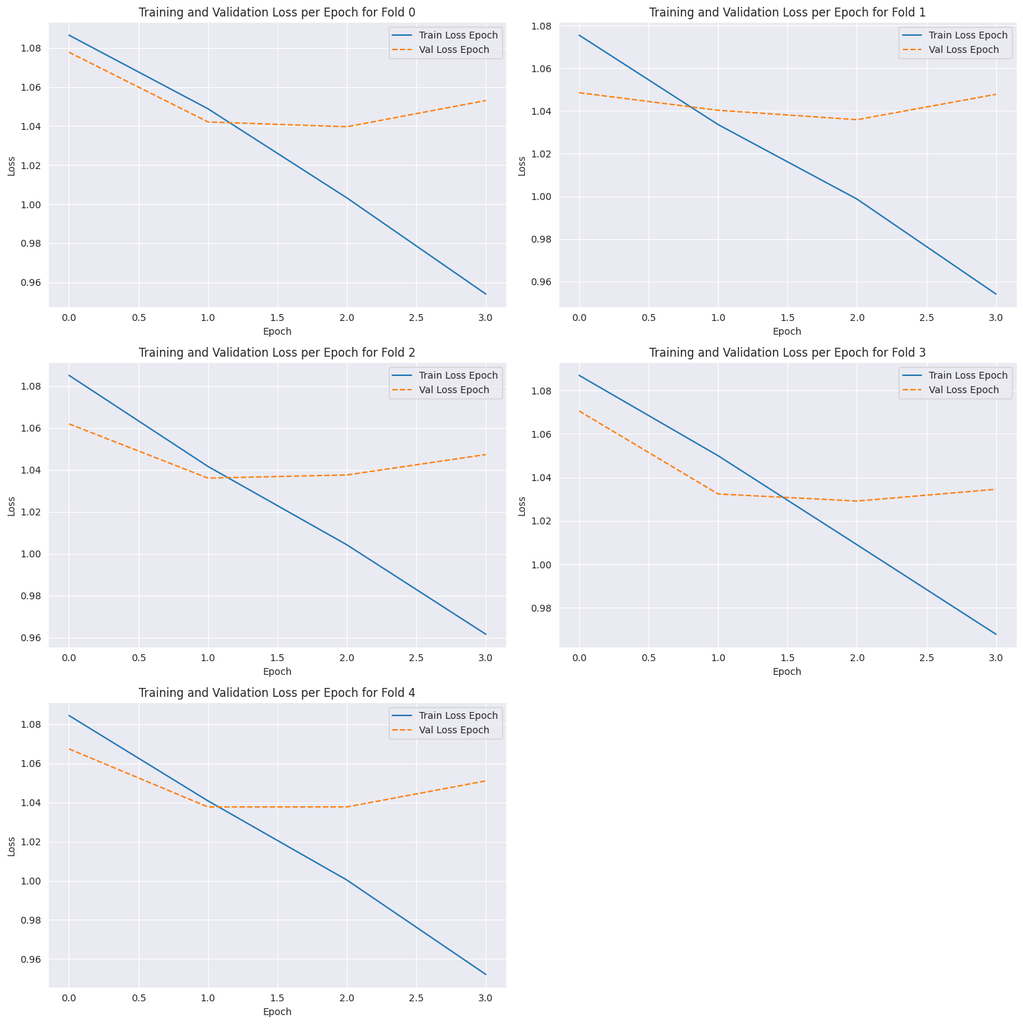

```python
# Plot logs for different fold
num_folds = len(df_logs)
num_cols = 2
num_rows = (num_folds + 1) // num_cols

fig, axs = plt.subplots(num_rows, num_cols, figsize=(15, num_rows * 5))
axs = axs.flatten()

for idx, (name, df) in enumerate(df_logs.items()):
    axs[idx].plot(df['epoch'], df['train_loss_epoch'], label='Train Loss Epoch')
    axs[idx].plot(df['epoch'], df['val_loss_epoch'], label='Val Loss Epoch', linestyle='--')
    axs[idx].set_xlabel('Epoch')
    axs[idx].set_ylabel('Loss')
    axs[idx].set_title(f'Training and Validation Loss per Epoch for Fold {idx}')
    axs[idx].legend()

for i in range(idx + 1, len(axs)):
    fig.delaxes(axs[i])

plt.tight_layout()
plt.show()
```

#### Training Results

The training and validation losses for each fold were tracked and plotted.

- **Fold 0**: The training loss consistently decreased across epochs, indicating the model was learning effectively. The validation loss showed some improvement but plateaued after the first epoch.
- **Fold 1**: Similar to Fold 0, the training loss decreased steadily, while the validation loss exhibited less improvement and slight fluctuations.
- **Fold 2**: The model showed a steady decrease in training loss. The validation loss decreased initially but then plateaued.
- **Fold 3**: This fold exhibited a consistent decrease in training loss, but the validation loss remained relatively flat, indicating potential overfitting.
- **Fold 4**: The training loss decreased as expected, with the validation loss showing initial improvement but then plateauing.

Overall, the model demonstrated effective learning during training, but the validation loss did not decrease as significantly, suggesting room for improvement in generalization.

```python
# Identify the best fold
best_fold = None
best_val_loss = float('inf')

for name, df in df_logs.items():
    if df['val_loss_epoch'].iloc[-1] < best_val_loss:
        best_val_loss = df['val_loss_epoch'].iloc[-1]
        best_fold = name

print(f"Best fold: {best_fold} with validation loss: {best_val_loss}")
```

```
Best fold: df_log_fold_3 with validation loss: 1.034535527229309
```

```python
best_fold_index = int(best_fold.split('_')[-1])
checkpoint_path = f'/content/model_fold_{best_fold_index}.ckpt'
```

## 3.2 Prediction and Submission

```python
class TokenizeTestDataset(Dataset):
    def __init__(self, dataframe, tokenizer, max_length):
        self.dataframe = dataframe
        self.tokenizer = tokenizer
        self.max_length = max_length

    def __len__(self):
        return len(self.dataframe)

    def __getitem__(self, index):
        row = self.dataframe.iloc[index]
        inputs = self.tokenizer(
            text=str(row['prompt']),
            text_pair=str(row['response_a']) + " [SEP] " + str(row['response_b']),
            truncation=True,
            padding='max_length',
            max_length=self.max_length,
            return_tensors="pt"
        )
        inputs = {key: val.squeeze(0) for key, val in inputs.items()}
        return inputs
```

```python
# Prediction
model = ClassificationModel.load_from_checkpoint(checkpoint_path, model_name=CFG.model, num_labels=CFG.num_labels, lr=CFG.lr, weight_decay=CFG.weight_decay, warmup_steps=CFG.warmup_ratio, total_steps=CFG.train_epochs * len(folders))

tokenizer = AutoTokenizer.from_pretrained(CFG.model)
test_dataset = TokenizeTestDataset(df_test, tokenizer, CFG.max_length)
test_loader = DataLoader(test_dataset, batch_size=CFG.eval_batch_size, shuffle=False)

def predict(model, test_loader):
    model.eval()
    all_probs = []
    for batch in test_loader:
        with torch.no_grad():
            outputs = model(**batch)
        probs = F.softmax(outputs.logits, dim=-1)
        all_probs.extend(probs.cpu().numpy())
    return all_probs

predictions = predict(model, test_loader)
pred_df = pd.DataFrame(predictions, columns=['winner_model_a', 'winner_model_b', 'winner_tie'])
pred_df.head()
```

```
Some weights of DebertaV2ForSequenceClassification were not initialized from the model checkpoint at microsoft/deberta-v3-xsmall and are newly initialized: ['classifier.bias', 'classifier.weight', 'pooler.dense.bias', 'pooler.dense.weight']
You should probably TRAIN this model on a down-stream task to be able to use it for predictions and inference.
```

|  | winner_model_a | winner_model_b | winner_tie |
| --- | --- | --- | --- |
| 0 | 0.274003 | 0.515597 | 0.210400 |
| 1 | 0.180159 | 0.498691 | 0.321150 |
| 2 | 0.390420 | 0.313013 | 0.296567 |

```python
# Prepare submission df
submission_df = df_test[['id']].copy()
submission_df = pd.concat([submission_df, pred_df], axis=1)
submission_df = submission_df[['id', 'winner_model_a', 'winner_model_b', 'winner_tie']]
submission_df.head()
```

|  | id | winner_model_a | winner_model_b | winner_tie |
| --- | --- | --- | --- | --- |
| 0 | 136060 | 0.274003 | 0.515597 | 0.210400 |
| 1 | 211333 | 0.180159 | 0.498691 | 0.321150 |
| 2 | 1233961 | 0.390420 | 0.313013 | 0.296567 |

```python
# Save to a CSV file
submission_df.to_csv('submission.csv', index=False)
```

```python
# Save best model and submission file
shutil.copy(checkpoint_path, "/content/drive/Shareddrives/Document/Projects/LMSYS_Project")
shutil.copy("/content/submission.csv", "/content/drive/Shareddrives/Document/Projects/LMSYS_Project")
```

```
'/content/drive/Shareddrives/Document/Projects/LMSYS_Project/submission.csv'
```

# 4. Conclusions

### 4.1 Objective

The primary objective of this project was to develop and evaluate a machine learning model capable of predicting user preferences between chatbot responses. Specifically, the goal was to create a model that could accurately classify responses as preferred by users using data from a Chatbot Arena competition. The model needed to predict three categories: `winner_model_a`, `winner_model_b`, and `winner_tie`.

### 4.2 Exploratory Data Analysis (EDA)

Before training the model, an Exploratory Data Analysis (EDA) was performed to understand the distribution and characteristics of the data. Visualizations and statistical analyses were conducted to identify patterns and insights that could inform the modeling process.

### 4.3 Training and Evaluation Process

1. **Model Selection**: I utilized Microsoft's DeBERTa-v3 model (`microsoft/deberta-v3-xsmall`), a state-of-the-art transformer-based model known for its superior performance on various NLP tasks.
2. **Cross-Validation**: A 5-fold cross-validation strategy was employed to ensure robust model evaluation. This involved splitting the data into five subsets, training on four subsets, and validating on the remaining subset, repeating this process five times.
3. **Loss Function**: The model used Cross-Entropy Loss during training, and the performance was evaluated using log loss on the validation set.
4. **Evaluation Metrics**: The validation performance was primarily measured using log loss, which is appropriate for evaluating the probability outputs of the model.

### 4.4 Future Improvements

1. **Hyperparameter Tuning**: Further tuning of hyperparameters such as learning rate, batch size, and weight decay might yield better results. Techniques like grid search or Bayesian optimization could be employed.
2. **Regularization Techniques**: Implementing additional regularization methods such as dropout or weight decay adjustments could help prevent overfitting.
3. **Data Augmentation**: Augmenting the training data with techniques like back-translation or synonym replacement could enhance the model's ability to generalize.
4. **Model Ensemble**: Combining the predictions of multiple models (ensemble learning) could improve the overall performance by reducing variance and bias.
5. **Advanced Architectures**: Exploring more advanced or larger transformer models, or fine-tuning specifically on similar task datasets, could yield performance gains.
6. **Extended Training**: Increasing the number of training epochs or using early stopping based on validation loss could help the model converge better and avoid overfitting.

### 4.5 Ongoing Kaggle Competition

It is important to note that this project is part of an ongoing Kaggle competition. So a submission score on Kaggle is not yet available. The competition's progress will provide further insights and potential areas for model refinement based on leaderboard performance and feedback.

### 4.6 Final Thoughts

This project successfully implemented a transformer-based model to predict user preferences between chatbot responses. While the model showed promise, especially in training performance, the validation results highlighted areas for improvement. By addressing these through hyperparameter tuning, regularization, data augmentation, and exploring more advanced architectures, the model's performance can be enhanced further, leading to more accurate predictions in real-world applications.